# Group Project: Identification of NMD sensitive RNAs and isoforms with long-read direct RNA sequencing(DRS)

Author

Tobia Ochsner, Michael Cibien, Gonzalo Cardenal Antolin (GonzaloCardenalAl)

Published

January 10, 2024

## Load packages

```r
suppressPackageStartupMessages({
library(limma) # replace this with packages you will use
library(ggplot2)
library(DESeq2)
library(tximport)
library(tidyverse)
library(biomaRt)
library(pheatmap)
library(RColorBrewer)
library(gplots)
library(pcaExplorer)
library(IsoformSwitchAnalyzeR)
library(calibrate)
library(MASS)
})
```

# Introduction

# Preprocessing

##Quality Control (QC) Data was already classified in different folders based on the Quality Control applied with Guppy. This step was done by the lab who provided the experimental data. Two scripts were generated to confirm the filtering heuristics applied during the quality control. We confirmed that the filtering criteria was filtering out reads witha q-score lower than 7. (Scripts available on the github repo under the name: “filter.r” & “checkGuppyFilter.r”). We also used Nanoplot, which provided with a report of different sequencing quality indicators (e.g. mean & median read quality, weighed histogram of read lengths…). These reports are also available in the group project GitHub repo. Also, we had reads from samples NP07 and NP08 divided in two folders NP07 & NP07B, and NP08 & NP08B. The reason for this is because during the sequencing process this stops in between so they had to restart the sequencing. Both subsamples were then merged during the mapping in one fatsq file. The results provided by Nanoplot confirmed that our samples were of optimal quality (mean read quality (q-score) > 7 and coherent read length distribution, sequencing error rates, and number of reads).

## Import Data

```r
samples <- list.files("counts_files")

raw_genomic <- sapply(samples, function(sample) {
  file <- paste0("counts_files/", sample, "/","primary-genomic-quant")
  quant <- read.table(file, header=TRUE, row.names=1, sep="\t")
  gene_id <- rownames(quant)
  raw <- quant[,6]
  raw_counts <- setNames(raw, gene_id)
  return(raw_counts)
})

raw_genomic <- as.data.frame(raw_genomic)

raw_genomic <- raw_genomic %>%
  rownames_to_column(var = "gene_name") %>%
  arrange(gene_name) %>%
  column_to_rownames(var = "gene_name")

head(raw_genomic)
```

```
                NP05-Scr1 NP06-dKD1 NP07-dKD2 NP08-Scr2
ENSG00000000003        62        50        83       100
ENSG00000000005         0         0         0         0
ENSG00000000419       118       111       184       182
ENSG00000000457         0         0         4         2
ENSG00000000460         0         0         0         0
ENSG00000000938         0         1         0         0
```

```r
#Transcriptomic data
np05_tcrm = read.table(file = 'counts_files/NP05-Scr1/transcriptomic-quant.tsv', sep = '\t', header = TRUE)
np05_tcrm = data.frame(transcript_name = np05_tcrm$transcript_name, tpm_np05 = np05_tcrm$tpm)

np06_tcrm = read.table(file = 'counts_files/NP06-dKD1/transcriptomic-quant.tsv', sep = '\t', header = TRUE)
np06_tcrm = data.frame(transcript_name = np06_tcrm$transcript_name, tpm_np06 = np06_tcrm$tpm)

np07_tcrm = read.table(file = 'counts_files/NP07-dKD2/transcriptomic-quant.tsv', sep = '\t', header = TRUE)
np07_tcrm = data.frame(transcript_name = np07_tcrm$transcript_name, tpm_np07 = np07_tcrm$tpm)

np08_tcrm = read.table(file = 'counts_files/NP08-Scr2/transcriptomic-quant.tsv', sep = '\t', header = TRUE)
np08_tcrm = data.frame(transcript_name = np08_tcrm$transcript_name, tpm_np08 = np08_tcrm$tpm)

tpm_transcriptome <- Reduce(function(x, y) merge(x, y, by = "transcript_name", all = TRUE), list(np05_tcrm, np06_tcrm, np07_tcrm, np08_tcrm))

# Rename columns to specify the dataset source

tpm_transcriptome <- as.data.frame(tpm_transcriptome)
tpm_transcriptome  <- tpm_transcriptome  %>%
  arrange(transcript_name) %>%
  column_to_rownames(var = "transcript_name")

head(tpm_transcriptome)
```

```
                      tpm_np05    tpm_np06   tpm_np07   tpm_np08
ENST00000000233.10 309.1542913 240.5310318 283.702478 336.004874
ENST00000000412.8   76.4575129  96.7413900  93.289284  94.624125
ENST00000000442.11   7.9517822   1.4499922   2.569157   8.118034
ENST00000001008.6    0.5540399   0.0000000   0.000000   0.000000
ENST00000001146.7    0.0000000   0.5624499   0.804218   2.201090
ENST00000002125.9   11.0807987  10.1240990   7.036907   9.337958
```

```r
#(this is useless)
target_transcript <- "ENST00000532829.5"

# Find the row where transcript_name matches the target_transcript
target_row <- np08_tcrm[np08_tcrm$transcript_name == target_transcript, ]

# Print the entire row or specific columns if needed
print(target_row)
```

```
    transcript_name tpm_np08
1 ENST00000532829.5 8765.227
```

## Exploratory Analysis

Once we obtain the genomic and transcriptomic counts of our samples, we run a initial exploratory analysis.

```r
colSums(raw_genomic)
```

```
NP05-Scr1 NP06-dKD1 NP07-dKD2 NP08-Scr2
   882803    877859   1239173   1323920
```

```r
colSums(tpm_transcriptome)
```

```
tpm_np05 tpm_np06 tpm_np07 tpm_np08
   1e+06    1e+06    1e+06    1e+06
```

```r
#Do we really need to normalise with long reads? No, but then what about the difference in raw genomic counts?
median_all_counts = median(colSums(raw_genomic))
scaling_factors = median(colSums(raw_genomic))/colSums(raw_genomic)
normalised_genomic=sweep(raw_genomic, 2, scaling_factors, `*`)

colSums(normalised_genomic)
```

```
NP05-Scr1 NP06-dKD1 NP07-dKD2 NP08-Scr2
  1060988   1060988   1060988   1060988
```

```r
log_normalised_genomic=log1p(normalised_genomic)

melted_data <- reshape2::melt(log_normalised_genomic)
colnames(melted_data) <- c("sample","Log_normalised_expression")

violin_plot_allgenes <- ggplot(melted_data, aes(x=sample, y=Log_normalised_expression, fill=sample)) +
  geom_violin() +
  labs(title='Violoin Plot of all samples Gene Log Expression Distribution', x='samples',y='Log expression')
  theme(plot.title = element_text(hjust = 0.5))
```

[output not shown]

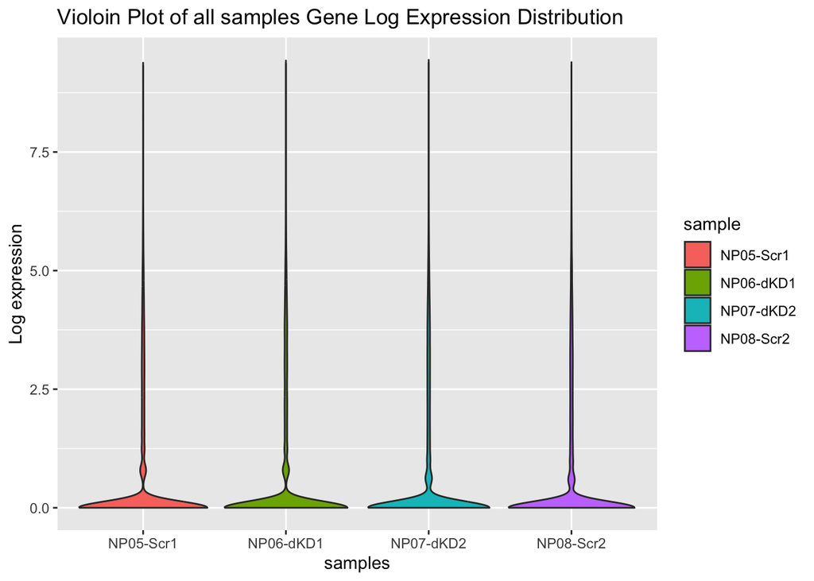

```r
print(violin_plot_allgenes)
```

All samples have similar gene expression distributions by looking at the violin plots.

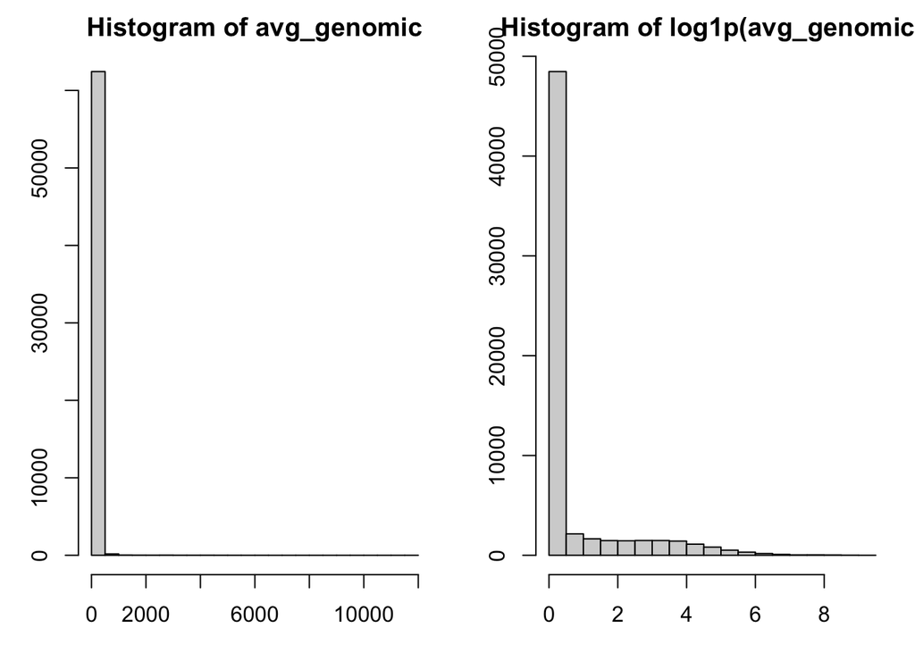

```r
avg_genomic <- rowMeans(raw_genomic)

par(mfrow = c(1, 2))
layout(matrix(1:2, nrow = 1))
par(mar = c(3, 3, 2, 1))
hist(avg_genomic)
hist(log1p(avg_genomic))
```

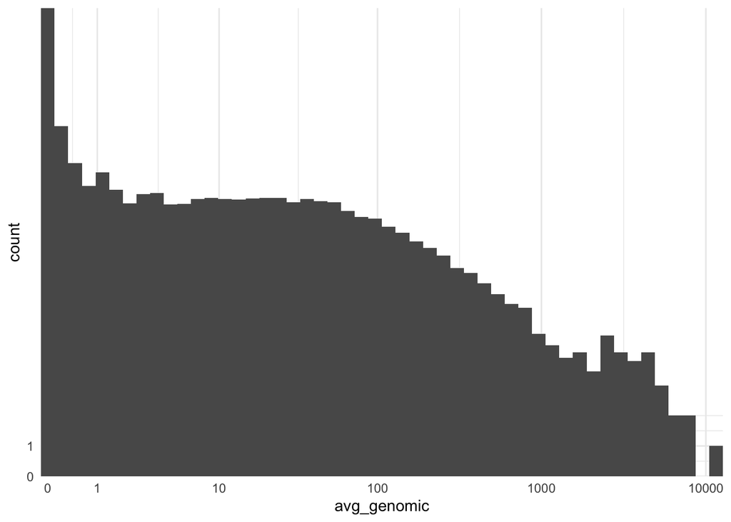

```r
ggplot(data.frame(avg_genomic), aes(x=avg_genomic)) +
  geom_histogram(bins = 50) +
  scale_x_continuous(breaks = c(0,1,10,100,1000,10000,20000), trans="log1p", expand=c(0,0)) +
  scale_y_continuous(breaks = c(0,1), expand=c(0,0), trans="log1p") +
  theme_minimal()
```

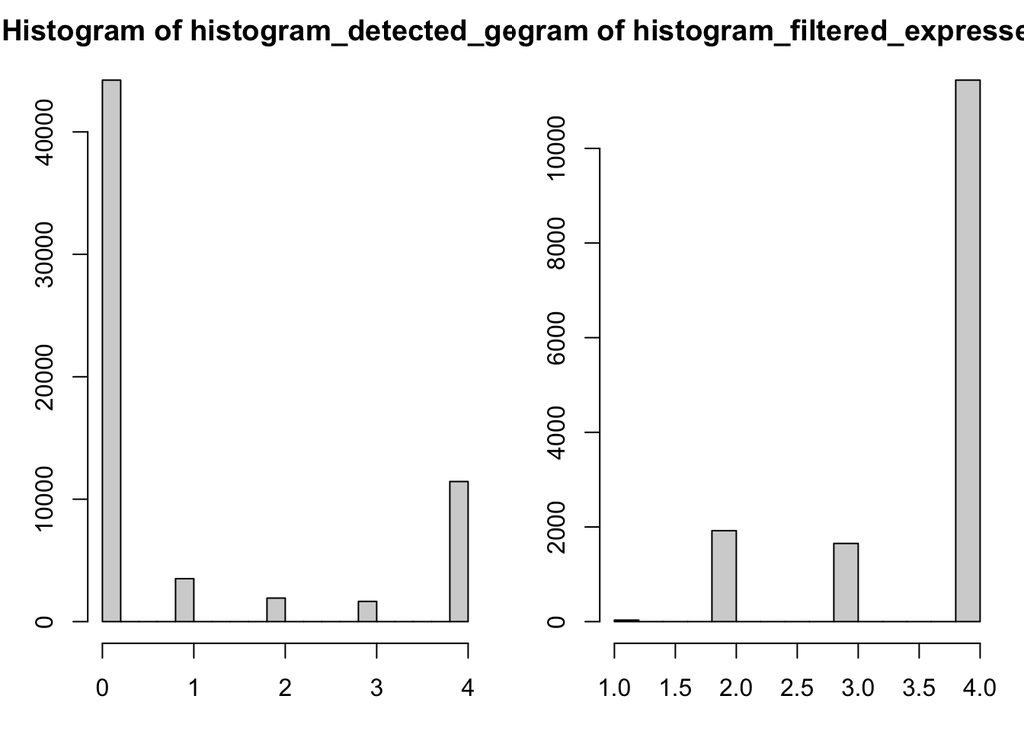

```r
histogram_detected_genes <- rowSums(raw_genomic > 0)
hist(histogram_detected_genes)

#This filtering criteria is performed for TPM, here we have raw counts
expressed <- rowMeans(raw_genomic  > 0) >= 0.5 | rowMeans(raw_genomic) >= 1
histogram_filtered_expressed_genes <- rowSums(raw_genomic[expressed,] > 0)
hist(histogram_filtered_expressed_genes)
```

Our filtering criteria filtered not only all the genes not expressed in any of the samples but also most of the genes only expressed in one individual sample.

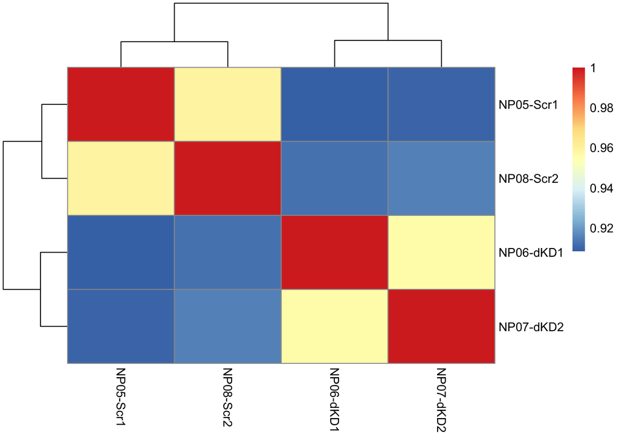

```r
#Plot heatmap
corr_pearson <- cor(log1p(raw_genomic[expressed,]))
pheatmap(corr_pearson)
```

## Differential Gene Expression Analysis

```r
#this code is not needed too
ensembl <- useEnsembl(biomart = "ensembl",
                      dataset = "hsapiens_gene_ensembl")
tx2gene <- getBM(attributes = c("ensembl_transcript_id_version",
                                "ensembl_gene_id_version"),
                 filters = "ensembl_gene_id_version",
                 values = rownames(expr),
                 mart = ensembl) %>%
  dplyr::select(ensembl_transcript_id_version, ensembl_gene_id_version)
```

```r
#DESeq input
raw_genomic<- as.matrix(raw_genomic)
condition <- factor(c("control","knockdown","knockdown","control")) #NP05-Scr1, NP06-dKD1, NP07-dKD2, NP08-Scr2
(coldata <- data.frame(row.names=colnames(raw_genomic), condition))
```

```
          condition
NP05-Scr1   control
NP06-dKD1 knockdown
NP07-dKD2 knockdown
NP08-Scr2   control
```

```r
# Make DESeq dataset
dds <- DESeqDataSetFromMatrix(countData=raw_genomic, colData=coldata, design=~condition)
dds
```

```
class: DESeqDataSet
dim: 62754 4
metadata(1): version
assays(1): counts
rownames(62754): ENSG00000000003 ENSG00000000005 ... ENSG00000292372
  ENSG00000292373
rowData names(0):
colnames(4): NP05-Scr1 NP06-dKD1 NP07-dKD2 NP08-Scr2
colData names(1): condition
```

```r
# Optional filtering step to remove very low counts (chosen minimum of 5)
keep <- rowSums(counts(dds)) >= 5
dds <- dds[keep,]

# Run DESeq2 pipeline
dds <- DESeq(dds)
res <- DESeq2::results(dds)
res
```

```
log2 fold change (MLE): condition knockdown vs control
Wald test p-value: condition knockdown vs control
DataFrame with 12939 rows and 6 columns
                 baseMean log2FoldChange     lfcSE       stat    pvalue
                <numeric>      <numeric> <numeric>  <numeric> <numeric>
ENSG00000000003  71.15309     -0.3257766  0.316642 -1.0288486  0.303551
ENSG00000000419 143.64052     -0.0706369  0.227744 -0.3101595  0.756440
ENSG00000000457   1.24498      0.9671047  2.550072  0.3792461  0.704505
ENSG00000001036  16.90446      0.0497611  0.664812  0.0748498  0.940334
ENSG00000001084   7.01765     -0.5919908  0.995149 -0.5948766  0.551926
...                   ...            ...       ...        ...       ...
ENSG00000292348 189.15052      0.1779944  0.197726   0.900206 0.3680104
ENSG00000292357  10.22278      1.4422616  0.848663   1.699451 0.0892342
ENSG00000292358  41.25677     -0.0652091  0.411644  -0.158411 0.8741326
ENSG00000292366  31.81156      0.7044188  0.484724   1.453238 0.1461577
ENSG00000292372   3.62745      1.2337631  1.475494   0.836170 0.4030594
                     padj
                <numeric>
ENSG00000000003  0.562073
ENSG00000000419  0.890040
ENSG00000000457        NA
ENSG00000001036  0.977413
ENSG00000001084  0.764897
...                   ...
ENSG00000292348  0.624072
ENSG00000292357  0.264707
ENSG00000292358  0.949564
ENSG00000292366  0.363055
ENSG00000292372        NA
```

```r
#DESeq2 results
table(res$padj<0.05)
```

```
FALSE  TRUE
 7271  1654
```

```r
res <- res[order(res$padj), ]

# Merge with normalized count data
resdata <- merge(as.data.frame(res), as.data.frame(counts(dds, normalized=TRUE)), by="row.names", sort=FALSE)
names(resdata)[1] <- "Gene"
head(resdata)
```

```
             Gene  baseMean log2FoldChange      lfcSE     stat        pvalue
1 ENSG00000224032 1000.8274       4.307767 0.13936391 30.91021 8.709885e-210
2 ENSG00000169242  886.1724       3.720117 0.13127462 28.33843 1.162292e-176
3 ENSG00000107262 1221.1706       2.555759 0.09930271 25.73705 4.501466e-146
4 ENSG00000210082 7819.4672       1.723809 0.06830571 25.23668 1.586237e-140
5 ENSG00000116761  605.5634       3.286235 0.14590196 22.52358 2.438256e-112
6 ENSG00000211459 3961.3526       1.490358 0.06967320 21.39070 1.630984e-101
           padj NP05-Scr1 NP06-dKD1 NP07-dKD2 NP08-Scr2
1 7.773572e-206   89.5916  1837.283  1975.093  101.3427
2 5.186729e-173  130.0919  1611.611  1681.869  121.1169
3 1.339186e-142  351.0027  2086.889  2088.384  358.4071
4 3.539291e-137 3424.1174 11737.182 12278.729 3837.8402
5 4.352287e-109  101.8644  1114.679  1084.593  121.1169
6  2.426088e-98 2055.6977  6056.650  5632.055 2101.0074
```

```r
resdata$DE <-resdata$padj<0.05
```

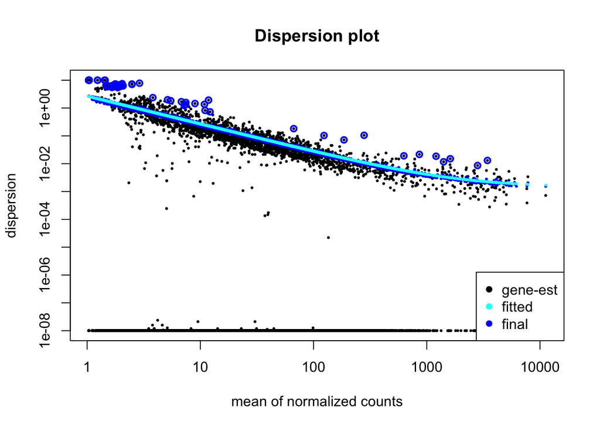

```r
# Plot dispersions
plotDispEsts(dds, main="Dispersion plot", genecol = "black", fitcol = "cyan", finalcol = "blue", legend = TRUE)
```

```r
# RLD for viewing
rld <- rlogTransformation(dds)
head(assay(rld))
```

```
                NP05-Scr1 NP06-dKD1 NP07-dKD2 NP08-Scr2
ENSG00000000003 6.1967911 5.9962192 6.1280413  6.257504
ENSG00000000419 7.1716479 7.0662760 7.2175104  7.199791
ENSG00000000457 0.2748373 0.2734275 0.4314863  0.352281
ENSG00000001036 4.0017285 4.2260638 3.8802268  4.091684
ENSG00000001084 2.7739815 2.7136224 2.7919250  2.937494
ENSG00000001167 2.1515362 2.0913369 1.9589217  2.108906
```

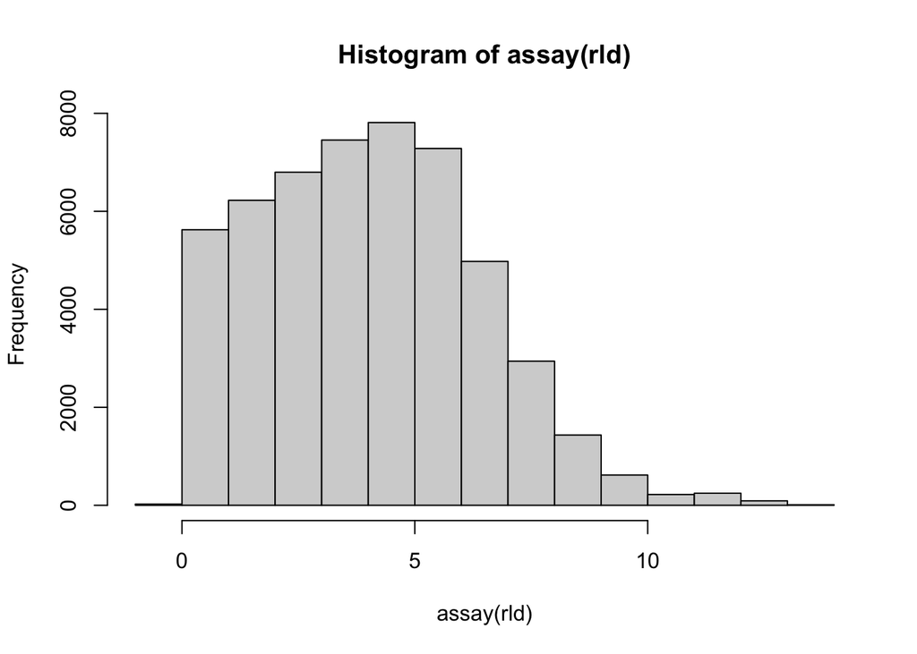

```r
hist(assay(rld))
```

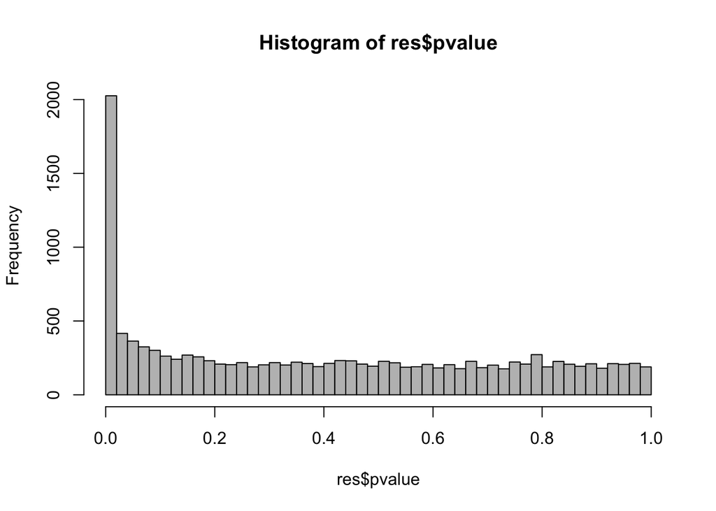

```r
# Plot residual p-values
hist(res$pvalue, breaks=50, col="grey")
```

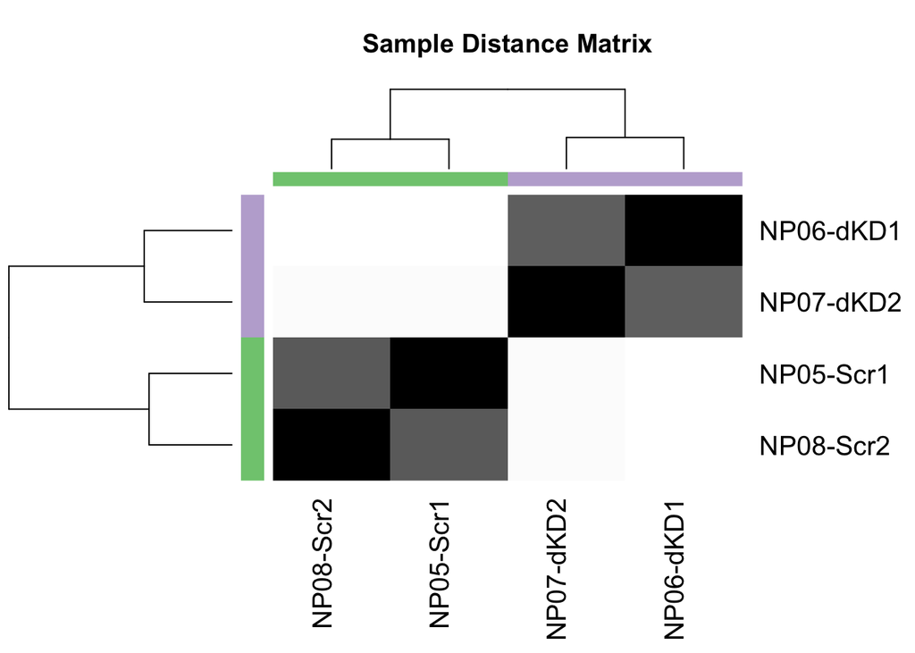

```r
#Set colours for plotting
mycols <- brewer.pal(8, "Accent")[1:length(unique(condition))]

# Heatmap
sampleDists <- as.matrix(dist(t(assay(rld))))
#png("heatmap-samples.png", w=1000, h=1000, pointsize=20)
heatmap.2(as.matrix(sampleDists), key=F, trace="none",
          col=colorpanel(100, "black", "white"),
          ColSideColors=mycols[condition], RowSideColors=mycols[condition],
          margin=c(10, 10), main="Sample Distance Matrix")
```

```r
#dev.off()

# PCA
rld_pca <- function (rld, intgroup = "condition", ntop = 500, colors=NULL, legendpos="bottomright", main="Principal Component Analysis", textcx=1, ...) {
  require(genefilter)
  require(calibrate)
  require(RColorBrewer)
  rv = rowVars(assay(rld))
  select = order(rv, decreasing = TRUE)[seq_len(min(ntop, length(rv)))]
  pca = prcomp(t(assay(rld)[select, ]))
  fac = factor(apply(as.data.frame(colData(rld)[, intgroup, drop = FALSE]), 1, paste, collapse = " : "))
  if (is.null(colors)) {
    if (nlevels(fac) >= 3) {
      colors = brewer.pal(nlevels(fac), "Paired")
    }   else {
      colors = c("black", "red")
    }
  }
  pc1var <- round(summary(pca)$importance[2,1]*100, digits=1)
  pc2var <- round(summary(pca)$importance[2,2]*100, digits=1)
  pc1lab <- paste0("PC1: ",as.character(pc1var),"% variance")
  pc2lab <- paste0("PC2: ",as.character(pc2var),"% variance")
  plot(PC2~PC1, data=as.data.frame(pca$x), bg=colors[fac], pch=21, xlab=pc1lab, ylab=pc2lab, main=main, ...)
  with(as.data.frame(pca$x), textxy(PC1, PC2, labs=rownames(as.data.frame(pca$x)), cex=textcx))
  legend(legendpos, legend=levels(fac), col=colors, pch=20)
}
png("pca-1-2.png", 1000, 1000, pointsize=30)
rld_pca(rld, colors=mycols, intgroup="condition", xlim=c(-10, 15), ylim=c(-10, 10))


# MA Plot
maplot <- function (res, thresh=0.05, labelsig=FALSE, textcx=1, ...) {
  with(res, plot(baseMean, log2FoldChange, pch=20, cex=.5, log="x", ...))
  with(subset(res, padj<thresh), points(baseMean, log2FoldChange, col="blue", pch=20, cex=1))
  if (labelsig) {
    require(calibrate)
    with(subset(res, padj<thresh), textxy(baseMean, log2FoldChange, labs=Gene, cex=textcx, col=2))
  }
}
png("diffexpr-maplot-0.05.png", 1500, 1000, pointsize=20)
maplot(resdata, main="MA Plot")

# Volcano Plot
volcanoplot <- function (res, lfcthresh=2, sigthresh=0.05, xlab="log2(Fold Change)", legendpos="topright", labelsig=FALSE, textcx=1.5, ...) {
  with(res, plot(log2FoldChange, -log10(pvalue), pch=20, xlab=xlab, cex.axis=1.8, cex.lab=1.5, ...))
  with(subset(res, padj<sigthresh ), points(log2FoldChange, -log10(pvalue), pch=20, col="blue", ...))
  with(subset(res, abs(log2FoldChange)>lfcthresh), points(log2FoldChange, -log10(pvalue), pch=20, col="orange", ...))
  with(subset(res, padj<sigthresh & abs(log2FoldChange)>lfcthresh), points(log2FoldChange, -log10(pvalue), pch=20, col="green", ...))
  legend(legendpos, xjust=1, yjust=1, legend=c(paste("p-adj<",sigthresh,sep=""), paste("|log2(FC)|>",lfcthresh,sep=""), "both"), cex=1.5, pch=20, col=c("blue","orange","green"))
}
#pdf("diffexpr-volcanoplot-hi-res.pdf", 18, 15, pointsize=20)
volcanoplot(resdata, lfcthresh=2, sigthresh=0.05, xlim=c(-6, 6), ylim=c(0,33), legendpos="topright")
```

# Differential Transcript Usage

```r
sampleID = c("tpm_np05","tpm_np06","tpm_np07","tpm_np08")
myDesign = data.frame(sampleID= sampleID, condition = condition)
tpm_transcriptome$isoform_id <- rownames(tpm_transcriptome)

aSwitchList <- importRdata(
  isoformCountMatrix   = tpm_transcriptome,
  isoformRepExpression = tpm_transcriptome,
  designMatrix         = myDesign,
  isoformExonAnnoation = "files/Homo_sapiens.GRCh38.110.chr_patch_hapl_scaff.gtf",
  isoformNtFasta       = "files/transcriptome_reference.fa",
  showProgress = FALSE
)
```

```
Step 1 of 10: Checking data...
```

```
Step 2 of 10: Obtaining annotation...
```

```
    importing GTF (this may take a while)...
```

```
    127644 ( 61.59%) isoforms were removed since they were not expressed in any samples.
```

```
Step 3 of 10: Fixing StringTie gene annoation problems...
```

```
    There were no need to rescue any annotation
```

```
    16657 genes_id were assigned their original gene_id instead of the StringTie gene_id.
        This was only done when it could be done unambiguous.
```

```
Step 4 of 10: Calculating expression estimates from count data...
```

```
    Skipped as user supplied expression via the "isoformRepExpression" argument...
```

```
Step 5 of 10: Testing for unwanted effects...
```

```
    SVA analysis failed. No unwanted effects were added.
```

```
Step 6 of 10: Batch correcting expression estimates...
```

```
    Skipped as no batch effects were found or annoated...
```

```
Step 7 of 10: Extracting data from each condition...
```

```
Step 8 of 10: Making comparisons...
```

```
Step 9 of 10: Making switchAnalyzeRlist object...
```

```
Step 10 of 10: Guestimating differential usage...
```

```
    The GUESSTIMATED number of genes with differential isoform usage are:
```

```
            comparison estimated_genes_with_dtu
1 control vs knockdown               638 - 1062
```

```
Done
```

```r
SwitchListFiltered <- preFilter(
  switchAnalyzeRlist = aSwitchList,
  geneExpressionCutoff = 5,
  isoformExpressionCutoff = 5,
  removeSingleIsoformGenes = TRUE)
```

```
The filtering removed 59243 ( 85.63% of ) transcripts. There is now 9940 isoforms left
```

```r
SwitchListAnalyzed <- isoformSwitchTestDEXSeq(
  switchAnalyzeRlist = SwitchListFiltered,
  reduceToSwitchingGenes=TRUE,
  reduceFurtherToGenesWithConsequencePotential = FALSE,
  alpha = 0.05,
  dIFcutoff = 0.1,
  onlySigIsoforms = FALSE
)
```

```
Step 1 of 2: Testing each pairwise comparisons with DEXSeq (this might be a bit slow)...
```

```
    Estimated run time is: 4 min
```

```
Step 2 of 2: Integrating result into switchAnalyzeRlist...
```

```
    Isoform switch analysis was performed for 3526 gene comparisons (100%).
```

```
Total runtime: 0.23 min
```

```
Done
```

```r
extractSwitchSummary(SwitchListAnalyzed)
```

```
            Comparison nrIsoforms nrSwitches nrGenes
1 control vs knockdown        823        520     488
```

```r
summary_isoforms <- SwitchListAnalyzed$isoformFeatures
write.csv(summary_isoforms[(summary_isoforms$iso_biotype == "nonsense_mediated_decay"),], "NMD_isoformfeatures.tr.csv")

SwitchListAnalyzed <- analyzeORF(
  SwitchListAnalyzed,
  orfMethod = "longest",
  showProgress=FALSE
)
```

```
Step 1 of 3 : Extracting transcript sequences...
```

```
Step 2 of 3 : Locating potential ORFs...
```

```
Step 3 of 3 : Scanning for PTCs...
```

```
1662 putative ORFs were identified, analyzed and added.
```

```
Done
```

```r
SwitchListAnalyzed <- extractSequence(
  SwitchListAnalyzed,
  pathToOutput = 'counts_isoform_switch/',
  writeToFile=TRUE
)
```

```
Step 1 of 3 : Extracting transcript nucleotide sequences...
```

```
Step 2 of 3 : Extracting ORF AA sequences...
```

```
Step 3 of 3 : Preparing output...
```

```
The 'removeLongAAseq' and 'removeShortAAseq' arguments:
 Removed : 0 isoforms.
 Trimmed : 0 isoforms (to only contain the first 1000 AA)
```

```
Done
```